# Clustering Census Data with Divergences

```python
from __future__ import division
import pandas as pd
import numpy as np
import seaborn as sns
import matplotlib.pyplot as plt
from descartes import PolygonPatch
import matplotlib.patches as mpatches
from json import loads
from sklearn.cluster import AgglomerativeClustering

%matplotlib inline
```

### Motivation

Classifying census blocks map based on similar distributions of age, language, racial demographics

Intuitivly, a $0\% \rightarrow 5\%$ is more significant than a $ 80\% \rightarrow 84\%$ change

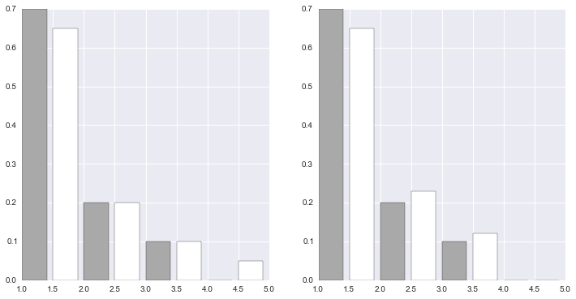

```python
a1 = np.array([0.7, 0.2, 0.1, 0.0])
b1 = np.array([0.65, 0.2, 0.1, 0.05])
sns.set_style("darkgrid")
fig, ax = plt.subplots(1, 2)
fig.set_size_inches(12, 6)
ax[0].bar([1, 2, 3, 4], a1, color="darkgrey", width=0.4)
ax[0].bar([1.5, 2.5, 3.5, 4.5], b1, color="white", width=0.4)


a2 = np.array([0.7, 0.2, 0.1, 0.0])
b2 = np.array([0.65, 0.23, 0.12, 0.0])
ax[1].bar([1, 2, 3, 4], a2, color="darkgrey", width=0.4)
ax[1].bar([1.5, 2.5, 3.5, 4.5], b2, color="white", width=0.4)
plt.show()
```

### Minkowski Distances

$$\left(\sum_{i=1}^n |x_i-y_i|^p\right)^{1/p}$$

### Cosine Similarity

Let A, B be vectors of length n containing the original counts from the data $$\theta = cos^{-1}\frac{(A \cdot B)}{||A|| \ ||B||}$$

The result of this for census data will be that $0 \leq \theta \leq \frac{\pi}{2}$

### KL-Divergence

Suppose that $D$ is a multinomial distribution with $k$ different parameters. Then the value of each parameter can be estimated as

$$ E[k_i] = \frac{X = i}{n} $$

Where $\sum \limits_{i=1}^k E[k_i] = 1$

We can treat the population breakdown percentage of each census block as the estimates of paramters for a specific realization from a multinomial distributions. Thinking of the population now as a random variable, the most meaningful comparison is a distance between probability distrubtions, The KL-divergence. To satisfy the requirements of a distance measure, the summetricized KL divergence is used

$$\frac{1}{2}D(P || Q) + \frac{1}{2}D(Q || p)$$

### Jensen-Shannon Divergence

Instead of computing M as the average of the probabilities, we add the counts and then recompute new probabilities $$JSD(P||Q) = \frac{1}{2}D(P||M) + \frac{1}{2}D(Q||M)$$

Where $M = \frac{1}{2}(Q + P)$

### Majority / Largest Minority

Common for racial demographics, formally $$ D(x, y) = \{ 0 \ if \ argmax(x) = argmax(y) \ else \ 1 \}$$

Where x and y are the original count vectors.

### Method

Updating Cluster Centers - use default methods first

Consider unique method, does it work better?

Instead of taking the cluster center as the mean of the members of probabilities, take it as the probability of the sum of the counts

### Applications

Some specific visualizations produced by faceting on grouping

### Citations

http://www.researchgate.net/profile/Flemming_Topsoe/publication/4109004_Jensen-Shannon_divergence_and_Hilbert_space_embedding/links/0c9605249611e4c842000000.pdf

```python
data = pd.read_csv("/Users/jonahwilliams/pdb2014bgv9_us.csv")
data = data[data.State_name == 'Nebraska']
data = data[(data.County_name == "Douglas County") |
            (data.County_name == "Sarpy County")
           ]
data = data[['GIDBG','Hispanic_CEN_2010',
            'NH_White_alone_CEN_2010',
            'NH_Blk_alone_CEN_2010',
            'NH_AIAN_alone_CEN_2010',
            'NH_Asian_alone_CEN_2010',
            'NH_NHOPI_alone_CEN_2010',
            'NH_SOR_alone_CEN_2010']].copy()
data.index = data.GIDBG
data = data.drop('GIDBG', axis=1)
```

```python
data = data + 1
data['Total'] = data.sum(axis=1)
data = data[data['Total'] > 7]
data = data.drop(['Total'], axis=1)
data.head()
```

| GIDBG | Hispanic_CEN_2010 | NH_White_alone_CEN_2010 | NH_Blk_alone_CEN_2010 | NH_AIAN_alone_CEN_2010 | NH_Asian_alone_CEN_2010 | NH_NHOPI_alone_CEN_2010 | NH_SOR_alone_CEN_2010 |
| --- | --- | --- | --- | --- | --- | --- | --- |
| 310550002001 | 38 | 714 | 446 | 7 | 2 | 1 | 2 |
| 310550002002 | 72 | 595 | 417 | 6 | 3 | 1 | 3 |
| 310550002003 | 22 | 550 | 58 | 7 | 2 | 1 | 1 |
| 310550002004 | 47 | 507 | 129 | 4 | 3 | 1 | 2 |
| 310550003001 | 57 | 140 | 430 | 15 | 2 | 1 | 1 |

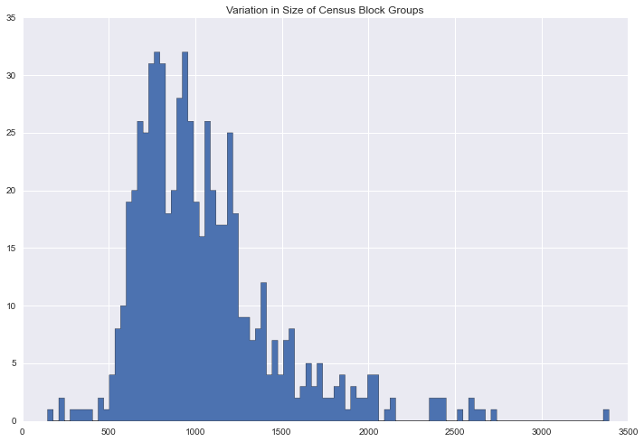

```python
plt.figure(figsize=(12,8))
sns.set_style("darkgrid")
plt.hist(np.sum(data, axis=1).values, histtype="stepfilled", bins=100)
plt.title("Variation in Size of Census Block Groups")
plt.show()
```

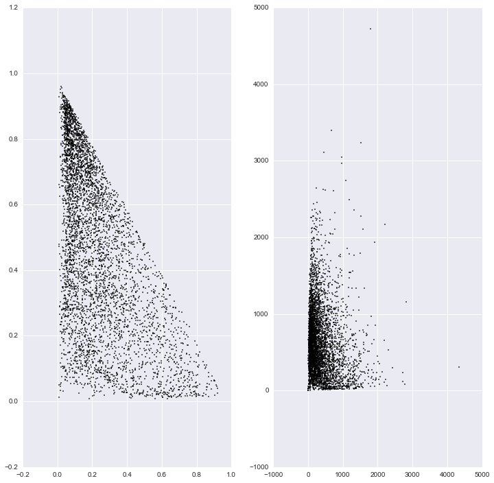

```python
fig, ax = plt.subplots(1, 2, sharex=False, sharey=False)
fig.set_size_inches(12, 12)

ax[1].scatter(data["Hispanic_CEN_2010"],
                    data["NH_White_alone_CEN_2010"],
                    s=2, color="black")

x = np.divide(data["Hispanic_CEN_2010"], np.sum(data, axis=1)).values
y = np.divide(data["NH_White_alone_CEN_2010"], np.sum(data, axis=1)).values
ax[0].scatter(x, y, s=2, color="black")
plt.show()
```

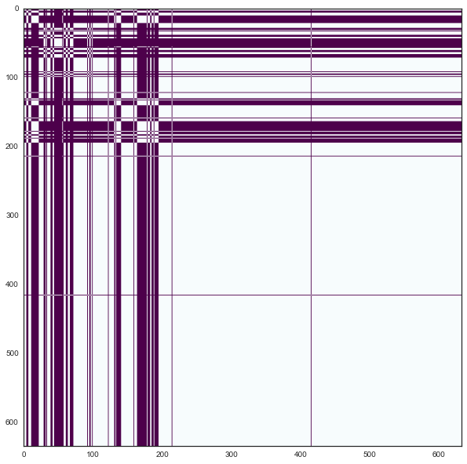

```python
#Majority Distance Matrix
argraw = np.argmax(data.values, axis=1)
n = len(data)
majority = np.zeros((n,n), np.int)

for i in xrange(n):
    for j in xrange(i, n):
        d = int(argraw[i] != argraw[j])
        majority[i][j] = d
        majority[j][i] = d

sns.set_style("white")
plt.figure(figsize=(10,10))
plt.imshow(majority, cmap="BuPu")
plt.show()
```

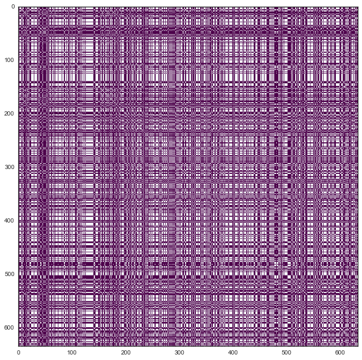

```python
#Largest Minority
argraw = np.argsort(data.values, axis=1)[:, 1]
n = len(data)
minority = np.zeros((n,n), np.int)

for i in xrange(n):
    for j in xrange(i, n):
        d = int(argraw[i] != argraw[j])
        minority[i][j] = d
        minority[j][i] = d

sns.set_style("white")
plt.figure(figsize=(10,10))
plt.imshow(minority, cmap="BuPu")
plt.show()
```

### Limitations of the Above measures

Because 'distance' is strictly 0 or 1, we are limited to a maximum number of classes - the number of columns of our data.

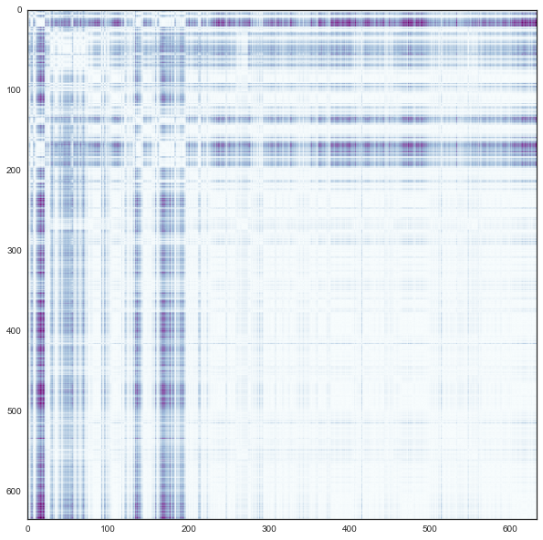

```python
# Calculate KL Divergence Distance Matrix
reduction = np.divide(data, np.sum(data, axis=1)[:,np.newaxis]).values
n = len(reduction)
entropies = np.sum((reduction * np.log(reduction)), axis=1)
logs = np.log(reduction)
kull_lieb = np.zeros((n, n), np.float64)

for i in xrange(n):
    for j in xrange(i, n):
        d = entropies[i] + entropies[j] - np.dot(reduction[j], logs[i]) - np.dot(reduction[i], logs[j])
        kull_lieb[j, i] = d
        kull_lieb[i, j] = d
kull_lieb = kull_lieb /  2

sns.set_style("white")
plt.figure(figsize=(10,10))
plt.imshow(kull_lieb, cmap="BuPu")
plt.show()
```

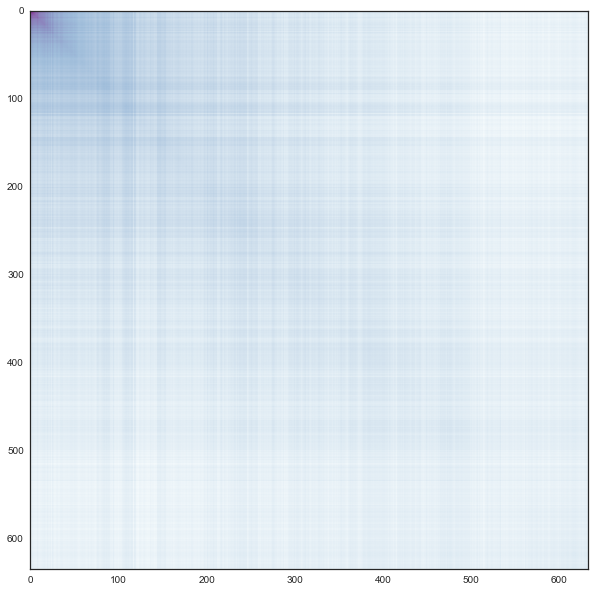

```python
# Calculate Jensen-Shannon divergence Matrix
p = np.divide(data, np.sum(data, axis=1)[:,np.newaxis]).values
n = len(p)
jensen_shannon = np.zeros((n, n), np.float64)
for i in xrange(n):
    for j in xrange(i, n):
        M = (p[i] + [j]) / 2
        d = np.dot(p[i], np.log(p[i] / M)) + np.dot(p[j], np.log(p[j] / M))
        jensen_shannon[j, i] = d
        jensen_shannon[i, j] = d
jensen_shannon = jensen_shannon /  2

sns.set_style("white")
plt.figure(figsize=(10,10))
plt.imshow(jensen_shannon, cmap="BuPu")
plt.show()
```

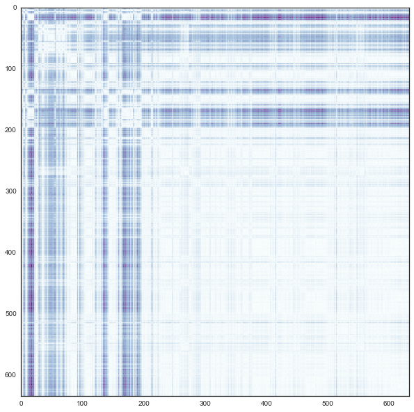

```python
# Modified Jensen Shannon
# Calculate Jensen-Shannon divergence Matrix

raw = data.values[:, 0:7]
p = np.divide(raw, np.sum(raw, axis=1)[:,np.newaxis])
n = len(p)
mod_jensen_shannon = np.zeros((n, n), np.float64)

for i in xrange(n):
    for j in xrange(i, n):
        M = np.divide(raw[i] + raw[j], np.sum(raw[i] + raw[j]))
        d = np.dot(p[i], np.log(p[i] / M)) + np.dot(p[j], np.log(p[j] / M))
        mod_jensen_shannon[j, i] = d
        mod_jensen_shannon[i, j] = d
mod_jensen_shannon = mod_jensen_shannon /  2

sns.set_style("white")
plt.figure(figsize=(10,10))
plt.imshow(mod_jensen_shannon, cmap="BuPu")
plt.show()
```

### Comparing Comparisons

Since Largest Minority weighting has a maximum of 5 classes for our particular dataset, we will compare the above distances using sklearns AgglomerativeClustering with 5 clusters as a standard

```python
from sklearn.cluster import AgglomerativeClustering
data['pred_kl'] = AgglomerativeClustering(n_clusters=5,
                        affinity="precomputed", linkage="average").fit_predict(kull_lieb)

data['pred_js'] = AgglomerativeClustering(n_clusters=5,
                        affinity="precomputed", linkage="average").fit_predict(jensen_shannon)

data['pred_modjs'] = AgglomerativeClustering(n_clusters=5,
                        affinity="precomputed", linkage="average").fit_predict(mod_jensen_shannon)
```

```python
data['pred_minority'] = np.argsort(data.values[:,0:7])[:,1]

def make_map(data, column):
    colors = sns.color_palette("husl", 7)
    sns.set_style("white")
    fig = plt.figure()
    ax = fig.gca()
    fig.set_size_inches(16, 12)

    map_data = loads(open("/Users/jonahwilliams/Downloads/NebraskaBlockGroups.json","r").read())

    for item in map_data['features']:
        poly = item['geometry']
        bg = int(item['properties']['GEOID'])
        try:
            a = data.loc[bg, column]
            ax.add_patch(PolygonPatch(poly, fc=colors[int(a) - 1], ec="black", alpha=0.9, zorder=2 ))
        except:
            pass
    ax.axis('scaled')
    plt.show()

def make_map_mult(data, columns):
    n = len(columns)
    colors = sns.color_palette("husl", 7)
    sns.set_style("white")
    for i, col in enumerate(columns):
        fig = plt.figure(i, figsize=(8, 8) )
        ax = fig.gca()

        map_data = loads(open("/Users/jonahwilliams/Downloads/NebraskaBlockGroups.json","r").read())

        for item in map_data['features']:
            poly = item['geometry']
            bg = int(item['properties']['GEOID'])
            try:
                a = data.loc[bg, col]
                ax.add_patch(PolygonPatch(poly, fc=colors[int(a) - 1], ec="black", alpha=0.9, zorder=2 ))
            except:
                pass
        ax.axis('scaled')
    plt.show()
```

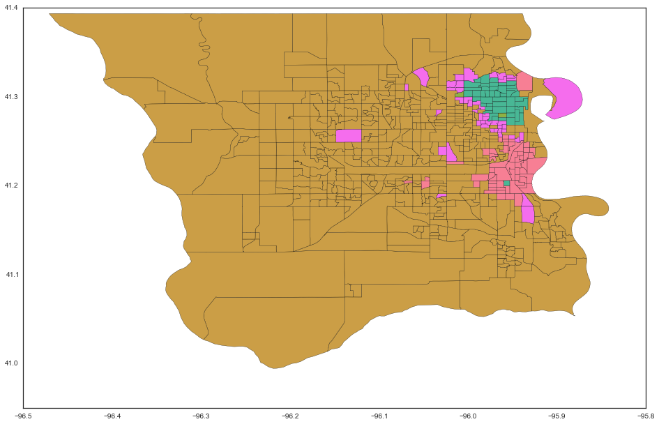

```python
make_map(data, "pred_kl")
```

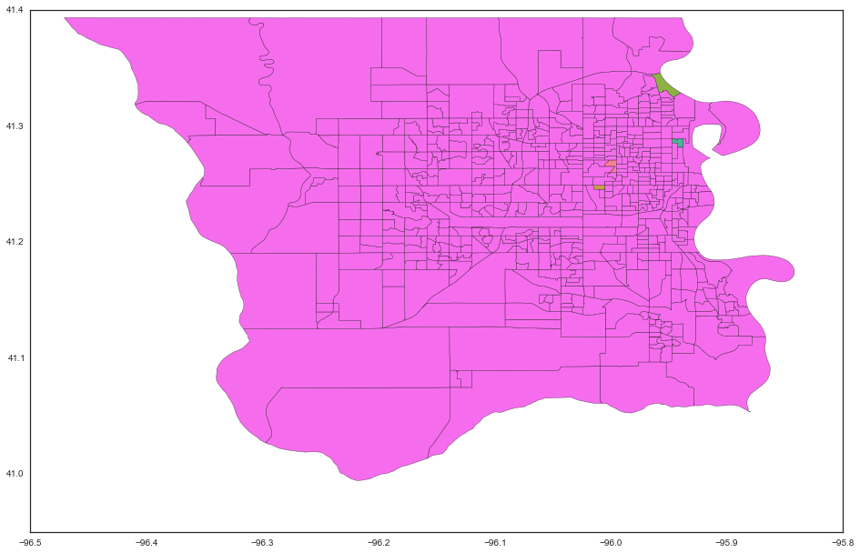

```python
make_map(data, "pred_js")
```

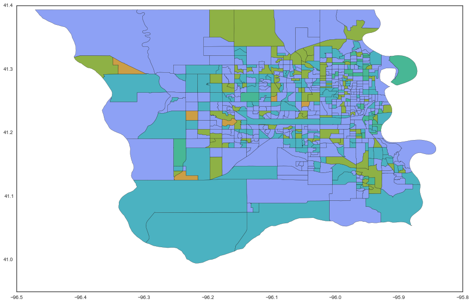

```python
make_map(data, "pred_minority")
```

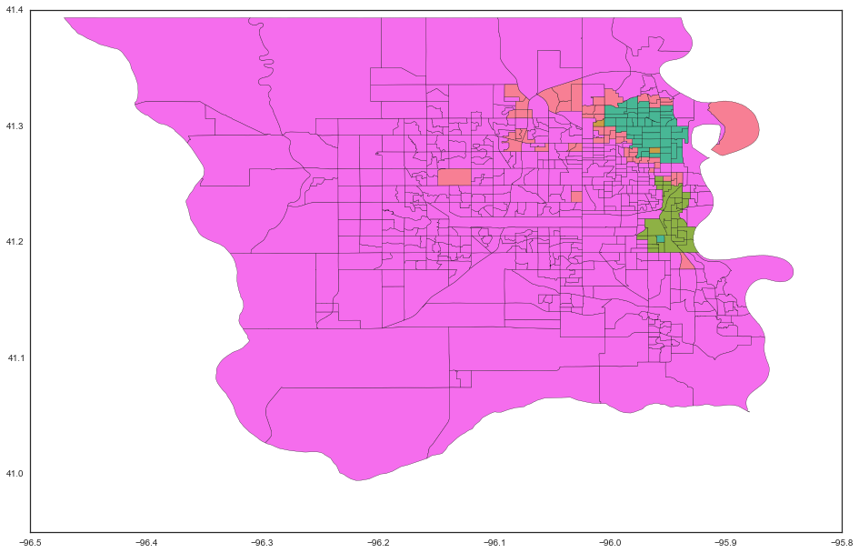

```python
make_map(data, "pred_modjs")
```

### Evaluating Clustering

For each clustering, we can define the cluster center as the proportions derived from the sum of all counts. We can then measure the distance from the cluster for all points inside and outside of the cluster

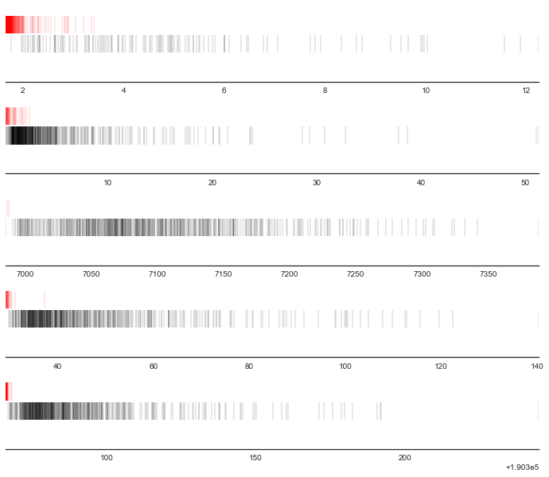

```python
centers = np.zeros((5, 7))
clusters = data.pred_modjs.values
raw = data.values[:,0:7]
for i in xrange(5):
    mask = (clusters == i)
    members = data.values[np.ix_(mask)][:,0:7]
    centers[i] = np.sum(members, axis=0)

fig, ax = plt.subplots(5, 1)
fig.set_size_inches(12, 10)
colors = ["black","red"]
for i in range(5):
    distances = np.zeros(len(data))
    proportions = data.values[:,0:7] / np.sum(data.values[:,0:7], axis=1)[:,np.newaxis]
    for j in xrange(len(data)):
        M = np.divide(raw[j] + centers[i], np.sum(raw[j] + centers[i]))
        distances[j] = (np.dot(proportions[j], np.log(proportions[j] / M)) + np.dot(centers[i], np.log(centers[i] / M)))/2

    ax[i].scatter(distances, map(lambda x: int(x == i)/10.0, data.pred_modjs),
                  color=map(lambda x: colors[int(x == i)], data.pred_modjs),
                  s=500, alpha=0.6, marker="|")
    ax[i].set_xlim(min(distances), max(distances))
    ax[i].set_ylim(-0.2, 0.2)
    ax[i].set_yticks([])

sns.despine(left=True)
```

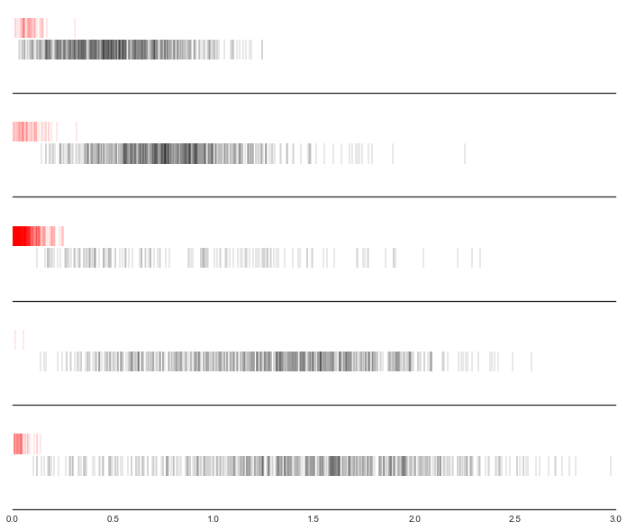

```python
centers = np.zeros((5, 7))
clusters = data.pred_kl.values
for i in xrange(5):
    mask = (clusters == i)
    members = data.values[np.ix_(mask)][:,0:7]
    centers[i] = np.sum(members, axis=0) / np.sum(np.sum(members, axis=0))


fig, ax = plt.subplots(5, 1, sharex=True)
fig.set_size_inches(12, 10)
colors = ["black","red"]
for i in range(5):
    distances = np.zeros(len(data))
    proportions = data.values[:,0:7] / np.sum(data.values[:,0:7], axis=1)[:,np.newaxis]
    distances = (np.sum(centers[i] * np.log(centers[i] / proportions), axis=1) +
            np.sum(proportions * np.log(proportions / centers[i]), axis=1)) / 2
    ax[i].scatter(distances, map(lambda x: int(x == i)/10.0, data.pred_kl),
                  color=map(lambda x: colors[int(x == i)], data.pred_kl),
                  s=500, alpha=0.6, marker="|")
    ax[i].set_xlim(0, 3)
    ax[i].set_ylim(-0.2, 0.2)
    ax[i].set_yticks([])

sns.despine(left=True)
```

### Algorithm

Randomly Initialize Cluster Centers - Draw from existing dataset

```python
def kmean(data):
    n_clusters =  5
    max_iterations = 1
    n = len(data)
    values = data.values[:,0:7]
    assignment = np.zeros((n, 1), np.int)
    kl = lambda x, y: (np.dot(x, np.log(x / y)) + np.dot(y, np.log(y / x))) / 2
    centers = (data.ix[np.random.choice(data.index, n_clusters)].values[:, 0:7] /
                np.sum(data.ix[np.random.choice(data.index, n_clusters)].values[:, 0:7], axis=1)[:, np.newaxis])
    iterations = 0



    while(iterations < max_iterations):
        # Compute Membership
        for i in xrange(n):
            distances = np.zeros(n_clusters, np.float)
            for j in xrange(n_clusters):
                distances[j] = kl(values[i] / np.sum(values[i]), centers[j])
            assignment[i] = np.argmin(distances)

        centers = np.zeros((n_clusters, 7))

        #Move to new cluster center
        for i in xrange(n_clusters):
            mask = (assignment == i)[:,0]
            members = values[np.ix_(mask)]
            centers[i] = np.sum(members, axis=0) / np.sum(np.sum(members, axis=0))
        iterations += 1
    return assignment
```

```python
kmean(data)
# data['kmeans_2'] = kmean(data, 5, 1)
# data['kmeans_3'] = kmean(data, 5, 1)
# data['kmeans_4'] = kmean(data, 5, 1)
# data['kmeans_5'] = kmean(data, 5, 1)
# data['kmeans_6'] = kmean(data, 5, 1)
# data['kmeans_7'] = kmean(data, 5, 1)
# data['kmeans_8'] = kmean(data, 5, 1)
# data['kmeans_9'] = kmean(data, 5, 1)
# make_map_mult(data, ["kmeans_" + str(i) for i in xrange(1, 10)])
```

[output not shown]

[output not shown]

```python
from sklearn.cross_validation import StratifiedKFold

temp = data.groupby(['kmeans']).sum() / np.sum(data.groupby(['kmeans']).sum(), axis=0)
temp = temp[['Hispanic_CEN_2010',
            'NH_White_alone_CEN_2010',
            'NH_Blk_alone_CEN_2010',
            'NH_AIAN_alone_CEN_2010',
            'NH_Asian_alone_CEN_2010',
            'NH_NHOPI_alone_CEN_2010',
            'NH_SOR_alone_CEN_2010']]
```

```python
kernel_matrix = np.dot(temp.values, temp.values.T)
```

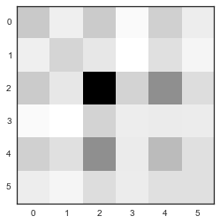

```python
plt.imshow(kernel_matrix, interpolation="nearest")
```

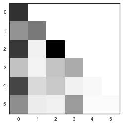

```python
covariance_matrix = np.linalg.cholesky(kernel_matrix + 1e-15 * np.eye(6))
plt.imshow(covariance_matrix, interpolation="nearest")
```

```python
argraw.shape
```

[output not shown]

```python
data.values[:,0:6].shape
```

[output not shown]

```python
cossim
```

[output not shown]

```python
cossim[np.isnan(cossim)].shape
```

```
(1171,)
```

```python
np.unique(np.argsort(data.values[:,0:7])[:,1])
```

```
array([2, 3, 4, 5, 6])
```

```python
data.values[:,0:7] / np.sum(data.values[:,0:7], axis=1)[:,np.newaxis]
```

```
array([[ 0.04165196,  0.73385104,  0.04977056, ...,  0.1613131 ,
         0.00317684,  0.00917755],
       [ 0.06864754,  0.8545082 ,  0.00717213, ...,  0.06454918,
         0.00102459,  0.00204918],
       [ 0.09378408,  0.77862595,  0.02835333, ...,  0.09269357,
         0.00109051,  0.00327154],
       ...,
       [ 0.20127389,  0.66751592,  0.00254777, ...,  0.01528662,
         0.00254777,  0.00382166],
       [ 0.07666667,  0.88833333,  0.00666667, ...,  0.01666667,
         0.00166667,  0.00166667],
       [ 0.09611452,  0.87014315,  0.00408998, ...,  0.01635992,
         0.00408998,  0.00511247]])
```

```python
i = 0
```

```python
min(distances)
```

```
0.017763132724721901
```

```python
M
```

```
array([ 0.17342029,  0.24472115,  0.0341561 ,  0.0023674 ,  0.53612654,
        0.0061213 ,  0.00308723])
```

```python
centers[i]
```

```
array([ 290210.,  408810.,   57173.,    3959.,  897455.,   10243.,    5163.])
```

```python
data
```

| GIDBG | Hispanic_CEN_2010 | NH_White_alone_CEN_2010 | NH_Blk_alone_CEN_2010 | NH_AIAN_alone_CEN_2010 | NH_Asian_alone_CEN_2010 | NH_NHOPI_alone_CEN_2010 | NH_SOR_alone_CEN_2010 | pred_kl | pred_js | pred_modjs | pred_minority |
| --- | --- | --- | --- | --- | --- | --- | --- | --- | --- | --- | --- |
| 310550002001 | 38 | 714 | 446 | 7 | 2 | 1 | 2 | 0 | 0 | 1 | 4 |
| 310550002002 | 72 | 595 | 417 | 6 | 3 | 1 | 3 | 0 | 0 | 1 | 4 |
| 310550002003 | 22 | 550 | 58 | 7 | 2 | 1 | 1 | 2 | 3 | 0 | 6 |
| 310550002004 | 47 | 507 | 129 | 4 | 3 | 1 | 2 | 2 | 0 | 0 | 6 |
| 310550003001 | 57 | 140 | 430 | 15 | 2 | 1 | 1 | 4 | 0 | 4 | 6 |
| 310550003002 | 66 | 226 | 429 | 7 | 1 | 3 | 1 | 4 | 0 | 4 | 6 |
| 310550003003 | 77 | 183 | 496 | 11 | 1 | 1 | 13 | 4 | 0 | 4 | 5 |
| 310550004001 | 565 | 696 | 89 | 11 | 9 | 3 | 2 | 1 | 0 | 0 | 5 |
| 310550004002 | 72 | 636 | 42 | 17 | 3 | 1 | 1 | 2 | 0 | 0 | 6 |
| 310550005001 | 114 | 743 | 206 | 3 | 22 | 1 | 1 | 2 | 0 | 0 | 6 |
| 310550005002 | 188 | 628 | 349 | 46 | 8 | 2 | 8 | 0 | 0 | 1 | 4 |
| 310550006001 | 54 | 116 | 539 | 3 | 3 | 1 | 16 | 4 | 0 | 4 | 3 |
| 310550006002 | 41 | 187 | 389 | 16 | 2 | 1 | 7 | 4 | 0 | 4 | 4 |
| 310550007001 | 84 | 124 | 955 | 22 | 6 | 1 | 6 | 4 | 0 | 4 | 4 |
| 310550008001 | 60 | 68 | 497 | 4 | 4 | 1 | 1 | 4 | 0 | 4 | 6 |
| 310550008002 | 64 | 134 | 937 | 20 | 1 | 2 | 4 | 4 | 0 | 4 | 5 |
| 310550011001 | 98 | 57 | 911 | 6 | 3 | 1 | 6 | 4 | 0 | 4 | 4 |
| 310550011002 | 26 | 25 | 261 | 1 | 8 | 2 | 1 | 4 | 0 | 4 | 6 |
| 310550011003 | 135 | 187 | 822 | 11 | 37 | 1 | 7 | 4 | 0 | 4 | 6 |
| 310550012001 | 23 | 56 | 716 | 2 | 2 | 1 | 6 | 4 | 4 | 4 | 3 |
| 310550012002 | 78 | 40 | 549 | 10 | 3 | 1 | 1 | 4 | 0 | 4 | 6 |
| 310550012003 | 100 | 321 | 857 | 18 | 6 | 2 | 1 | 4 | 0 | 4 | 5 |
| 310550016001 | 52 | 927 | 54 | 17 | 150 | 5 | 2 | 2 | 0 | 0 | 5 |
| 310550016002 | 40 | 1138 | 46 | 11 | 92 | 3 | 2 | 2 | 0 | 0 | 5 |
| 310550018001 | 387 | 914 | 639 | 20 | 39 | 1 | 3 | 0 | 0 | 1 | 6 |
| 310550018002 | 63 | 975 | 36 | 12 | 24 | 2 | 2 | 2 | 0 | 0 | 6 |
| 310550018003 | 50 | 632 | 95 | 4 | 22 | 1 | 3 | 2 | 0 | 0 | 6 |
| 310550019001 | 47 | 297 | 75 | 5 | 22 | 1 | 2 | 2 | 0 | 1 | 6 |
| 310550019002 | 225 | 260 | 188 | 9 | 12 | 1 | 2 | 0 | 0 | 1 | 6 |
| 310550020001 | 636 | 314 | 15 | 23 | 1 | 2 | 5 | 1 | 0 | 3 | 5 |
| ... | ... | ... | ... | ... | ... | ... | ... | ... | ... | ... | ... |
| 311530106261 | 52 | 1788 | 17 | 2 | 28 | 1 | 1 | 2 | 0 | 0 | 6 |
| 311530106262 | 51 | 1328 | 6 | 3 | 29 | 1 | 3 | 2 | 0 | 0 | 3 |
| 311530106263 | 96 | 1563 | 14 | 1 | 50 | 1 | 3 | 2 | 0 | 0 | 5 |
| 311530106271 | 76 | 1103 | 13 | 2 | 23 | 1 | 4 | 2 | 0 | 0 | 3 |
| 311530106272 | 46 | 1465 | 18 | 2 | 18 | 1 | 5 | 2 | 0 | 0 | 3 |
| 311530106281 | 11 | 840 | 15 | 2 | 8 | 1 | 1 | 2 | 0 | 0 | 6 |
| 311530106282 | 19 | 1510 | 14 | 2 | 16 | 3 | 1 | 2 | 0 | 0 | 3 |
| 311530106283 | 78 | 1788 | 26 | 6 | 64 | 1 | 4 | 2 | 0 | 0 | 6 |
| 311530106291 | 25 | 659 | 21 | 2 | 26 | 1 | 1 | 2 | 0 | 0 | 6 |
| 311530106292 | 42 | 989 | 9 | 8 | 8 | 2 | 1 | 2 | 0 | 0 | 5 |
| 311530106301 | 67 | 2295 | 10 | 3 | 45 | 1 | 1 | 2 | 0 | 0 | 6 |
| 311530106311 | 36 | 1659 | 3 | 3 | 7 | 1 | 2 | 2 | 0 | 0 | 6 |
| 311530106312 | 13 | 994 | 9 | 1 | 1 | 1 | 1 | 2 | 0 | 0 | 4 |
| 311530106313 | 11 | 1023 | 13 | 1 | 5 | 1 | 1 | 2 | 0 | 0 | 5 |
| 311530106314 | 6 | 597 | 1 | 1 | 2 | 1 | 1 | 2 | 0 | 0 | 3 |
| 311530106321 | 37 | 1937 | 14 | 1 | 11 | 1 | 1 | 2 | 0 | 0 | 5 |
| 311530106322 | 19 | 552 | 7 | 4 | 4 | 1 | 2 | 2 | 0 | 0 | 6 |
| 311530106323 | 23 | 1243 | 2 | 7 | 7 | 1 | 4 | 2 | 0 | 0 | 2 |
| 311530106331 | 83 | 1323 | 32 | 7 | 24 | 1 | 3 | 2 | 0 | 0 | 6 |
| 311530106332 | 56 | 733 | 9 | 2 | 13 | 1 | 1 | 2 | 0 | 0 | 6 |
| 311530106333 | 39 | 647 | 2 | 7 | 4 | 1 | 1 | 2 | 0 | 0 | 6 |
| 311530106341 | 13 | 709 | 3 | 2 | 4 | 3 | 1 | 2 | 0 | 0 | 3 |
| 311530106342 | 85 | 943 | 19 | 4 | 2 | 1 | 1 | 2 | 0 | 0 | 6 |
| 311530106343 | 54 | 978 | 12 | 3 | 20 | 1 | 1 | 2 | 0 | 0 | 6 |
| 311530107011 | 32 | 1338 | 9 | 8 | 14 | 2 | 1 | 2 | 0 | 0 | 5 |
| 311530107012 | 4 | 860 | 7 | 2 | 1 | 1 | 1 | 2 | 0 | 0 | 5 |
| 311530107021 | 15 | 661 | 10 | 2 | 2 | 1 | 1 | 2 | 0 | 0 | 6 |
| 311530107022 | 14 | 930 | 2 | 1 | 3 | 1 | 1 | 2 | 0 | 0 | 5 |
| 311530107023 | 13 | 1105 | 1 | 2 | 5 | 1 | 1 | 2 | 0 | 0 | 5 |
| 311530107024 | 10 | 784 | 5 | 1 | 5 | 2 | 1 | 2 | 0 | 0 | 6 |

634 rows × 11 columns